# Hypothesis Tests in R

Summary statistics from Classes 18 and 19 · Fall 2026

STAT 312 · Case Western Reserve University

## Summary statistics for a mean test

Each example supplies a sample mean $\bar{x}$ and sample size $n$.

| Information about variability | Standard error | Reference distribution |
| --- | --- | --- |
| Population SD $\sigma$ is known | $\sigma/\sqrt{n}$ | Standard normal |
| Population SD is unknown, normal population | $s/\sqrt{n}$ | Student’s $t$, $df=n-1$ |
| Population SD is unknown, adequate large sample | $s/\sqrt{n}$ | Approximate standard normal |

If the problem gives a **variance**, take its square root to obtain the SD.

## R probability and quantile functions

| Task | Standard normal | Student’s $t$ |
| --- | --- | --- |
| Left-tail probability | `pnorm(z)` | `pt(t, df)` |
| Right-tail probability | `pnorm(z, lower.tail = FALSE)` | `pt(t, df, lower.tail = FALSE)` |
| Quantile from a left-tail area | `qnorm(p)` | `qt(p, df)` |

`qnorm()` corresponds to `invNorm()` and `qt()` corresponds to `invT()`.

For a two-sided test, add both tails using the **absolute** observed statistic.

Critical-value subscripts here denote **left-tail probabilities**.

## Class 18: Light-bulb lifetimes

An electrical firm models bulb lifetimes as approximately normal. The known population standard deviation is **40 hours**. An independent random sample of **30 bulbs** has mean lifetime **788 hours**.

Test whether the population mean differs from **800 hours**, using $\alpha=0.05$.

$$H_0:\mu=800,\qquad H_a:\mu\ne800.$$

Known $\sigma$ gives a Z-test. The alternative makes this a **two-sided** test.

## Light bulbs: Standard error and statistic

$$SE=\frac{\sigma}{\sqrt{n}},\qquad
z_{\mathrm{obs}}=\frac{\bar{x}-\mu_0}{SE}.$$

```r
xbar <- 788
sigma <- 40
n <- 30
mu0 <- 800
alpha <- 0.05
SE <- sigma / sqrt(n)
z_obs <- (xbar - mu0) / SE
round(c(SE = SE, z_obs = z_obs), 4)
```

```
     SE   z_obs
 7.3030 -1.6432
```

The negative statistic places the sample mean below the null mean.

## Light bulbs: Critical region

The two-sided test places $\alpha/2=0.025$ in each tail.

```r
critical <- qnorm(1 - alpha / 2)
round(c(lower = -critical,
        upper = critical), 4)
abs(z_obs) > critical
```

```
lower upper
-1.96  1.96
[1] FALSE
```

$$\text{Reject }H_0\text{ if }|Z|>1.9600.$$

The observed statistic lies outside the rejection region.

## Light bulbs: P-value and conclusion

$$p=2P\!\left(Z\ge |z_{\mathrm{obs}}|\right).$$

```r
p_value <- 2 * pnorm(
  abs(z_obs), lower.tail = FALSE
)
round(p_value, 6)
p_value <= alpha
```

```
[1] 0.100348
[1] FALSE
```

**Fail to reject $H_0$.** There is insufficient evidence at the 5% level that the population mean lifetime differs from 800 hours.

## Light bulbs: Matching 95% confidence interval

$$\bar{x}\pm z_{0.975}\frac{\sigma}{\sqrt{n}}.$$

```r
CI <- xbar + c(-1, 1) * critical * SE
names(CI) <- c("lower", "upper")
round(CI, 4)
CI[1] <= mu0 && mu0 <= CI[2]
```

```
   lower    upper
773.6864 802.3136
[1] TRUE
```

The interval **contains 800 hours**. This agrees with the two-sided test.

## Class 19: Battery operating life

A manufacturer claims a mean battery life of **75 hours**. Customer complaints suggest a smaller population mean.

An independent random sample gives $n=42$, $\bar{x}=60.1$ hours, and $s=18$ hours. Use $\alpha=0.05$.

$$H_0:\mu=75,\qquad H_a:\mu<75.$$

Apply the lecture’s **large-sample normal approximation**, using $s$ to estimate the unknown population standard deviation.

## Batteries: Estimated SE and statistic

$$\widehat{SE}=\frac{s}{\sqrt{n}},\qquad
z_{\mathrm{obs}}=\frac{\bar{x}-\mu_0}{\widehat{SE}}.$$

```r
xbar <- 60.1
s <- 18
n <- 42
mu0 <- 75
alpha <- 0.05
SE <- s / sqrt(n)
z_obs <- (xbar - mu0) / SE
round(c(SE = SE, z_obs = z_obs), 4)
```

```
     SE   z_obs
 2.7775 -5.3646
```

The standard error uses the **sample SD** $s$, not a known population SD.

## Batteries: Critical region and p-value

For the left-tailed test, reject when $Z<z_{0.05}$.

```r
critical <- qnorm(alpha)
p_value <- pnorm(z_obs)
round(critical, 4)
signif(p_value, 6)
c(critical_region = z_obs < critical,
  p_value_rule = p_value <= alpha)
```

```
[1] -1.6449
[1] 4.05615e-08
critical_region    p_value_rule
           TRUE            TRUE
```

**Reject $H_0$.** There is sufficient evidence that the population mean battery life is less than 75 hours.

## Batteries: A confidence bound for the left-tailed test

A matching 95% **upper confidence bound** has the form

$$\left(-\infty,\ \bar{x}+z_{0.95}\widehat{SE}\right).$$

```r
upper_bound <- xbar +
  qnorm(1 - alpha) * SE
round(upper_bound, 4)
mu0 > upper_bound
```

```
[1] 64.6685
[1] TRUE
```

The null value of 75 hours lies above the upper bound. Reject $H_0$.

## Batteries: Two-sided estimation interval

For a two-sided 95% interval, use $z_{0.975}$ and both endpoints.

```r
CI <- xbar + c(-1, 1) *
  qnorm(0.975) * SE
names(CI) <- c("lower", "upper")
round(CI, 4)
```

```
  lower   upper
54.6563 65.5437
```

The 95% confidence interval for the mean is **54.66 to 65.54 hours**.

This two-sided interval reports uncertainty in the mean. The previous slide’s one-sided bound matches the original left-tailed test.

## Class 19: Golf-driver coefficient of restitution

An independent random sample of **15 golf drivers** gives $\bar{x}=0.83725$ and $s=0.02456$ for the coefficient of restitution (COR). Assume a normal population with unknown standard deviation.

Test whether the population mean COR exceeds **0.82**, using $\alpha=0.05$.

$$H_0:\mu=0.82,\qquad H_a:\mu>0.82.$$

Use a right-tailed **t-test** with $df=15-1=14$.

## Golf drivers: Standard error and t-statistic

$$SE=\frac{s}{\sqrt{n}},\qquad
t_{\mathrm{obs}}=\frac{\bar{x}-\mu_0}{SE},\qquad df=n-1.$$

```r
xbar <- 0.83725
s <- 0.02456
n <- 15
mu0 <- 0.82
alpha <- 0.05
df <- n - 1
SE <- s / sqrt(n)
t_obs <- (xbar - mu0) / SE
round(c(SE = SE, t_obs = t_obs), 6)
```

```
      SE    t_obs
0.006341 2.720235
```

## Golf drivers: Critical region and p-value

The right-tailed test rejects when $T>t_{0.95,14}$.

```r
critical <- qt(1 - alpha, df = df)
p_value <- pt(t_obs, df = df,
              lower.tail = FALSE)
round(c(critical = critical,
        p_value = p_value), 6)
c(critical_region = t_obs > critical,
  p_value_rule = p_value <= alpha)
```

```
critical  p_value
1.761310 0.008293
critical_region    p_value_rule
           TRUE            TRUE
```

**Reject $H_0$.** There is sufficient evidence that the population mean COR exceeds 0.82.

## Golf drivers: Matching lower confidence bound

A matching 95% **lower confidence bound** is

$$\left(\bar{x}-t_{0.95,14}SE,\ \infty\right).$$

```r
lower_bound <- xbar -
  qt(1 - alpha, df = df) * SE
round(lower_bound, 6)
mu0 < lower_bound
```

```
[1] 0.826081
[1] TRUE
```

The null value of 0.82 lies below the lower bound. Reject $H_0$.

## Golf drivers: Two-sided 95% t interval

$$\bar{x}\pm t_{0.975,14}\frac{s}{\sqrt{n}}.$$

```r
CI <- xbar + c(-1, 1) *
  qt(0.975, df = df) * SE
names(CI) <- c("lower", "upper")
round(CI, 6)
```

```
   lower    upper
0.823649 0.850851
```

We are 95% confident that the population mean COR lies between **0.823649 and 0.850851**.

## Results for the three mean tests

| Example | Reference | Statistic | P-value | Decision at 5% |
| --- | --- | --- | --- | --- |
| Light bulbs | Standard normal | -1.6432 | 0.100348 | Fail to reject |
| Batteries | Approximate standard normal | -5.3646 | 4.056e-08 | Reject |
| Golf drivers | $t_{14}$ | 2.7202 | 0.008293 | Reject |

All three tests center the observed statistic at the **null mean** $\mu_0$.

The scientific question determines the tail. Population assumptions determine the reference distribution.

## Short practice: A different bulb sample

Keep $\sigma=40$ hours, $n=30$, $\mu_0=800$ hours, and $\alpha=0.05$. Suppose a new independent random sample has **$\bar{x}=780$ hours**.

1. Find the observed Z-statistic and the two-sided p-value.
2. State the decision and interpret it in context.
3. Construct the matching 95% confidence interval.

Predict whether the evidence will become stronger before calculating.

## Practice solution

```r
SE_new <- 40 / sqrt(30)
z_new <- (780 - 800) / SE_new
p_new <- 2 * pnorm(abs(z_new),
                  lower.tail = FALSE)
CI_new <- 780 + c(-1, 1) *
  qnorm(0.975) * SE_new
round(c(z = z_new, p = p_new,
        lower = CI_new[1],
        upper = CI_new[2]), 4)
```

```
       z        p    lower    upper
 -2.7386   0.0062 765.6864 794.3136
```

**Reject $H_0$.** There is sufficient evidence that the population mean differs from 800 hours. The interval lies entirely below 800 hours.

## Interpretation and assumptions

- The standard error is an SD divided by $\sqrt{n}$.
- A p-value uses the null distribution and the tail specified by $H_a$.
- A failure to reject $H_0$ does not establish that $H_0$ is true.
- Matching confidence sets use the same reference distribution and tail allocation.
- Summary statistics permit these calculations but cannot reveal outliers, dependence, or departures from normality.

## Propellant: Type I and Type II error

The air-crew escape system example tests the mean burning rate in cm/sec.

$$H_0:\mu=50,\qquad H_a:\mu\ne50,\qquad
SE=\frac{2.5}{\sqrt{n}}.$$

At $n=10$, the reference rule rejects outside **$[48.5,51.5]$**.

- **Red area:** $\alpha=P_{50}(\text{reject }H_0)$ under the null distribution.
- **Gold area:** $\beta(\mu_a)=P_{\mu_a}(\text{fail to reject }H_0)$ under a specified alternative.
- **Power:** $1-\beta(\mu_a)$, the chance of detecting that alternative.

The app compares **$\mu_a=52$** and **$\mu_a=50.5$**.

## Propellant: Live Shiny demonstration

Open app in a separate tab

### Sampling distributions and error areas

Predict which shaded area will grow before changing a setting.

1. **Alpha and beta:** move the critical boundaries.
2. **Sample size: cutoffs fixed:** compare the two alternative means.
3. **Sample size: alpha fixed:** narrow the distributions while keeping alpha unchanged.

This app runs in your browser. Click **Load live app** and allow time for the first startup. No R installation is required. The following slides also show the comparisons as figures.

[interactive chart not shown]

## Alpha and beta: Moving the boundaries

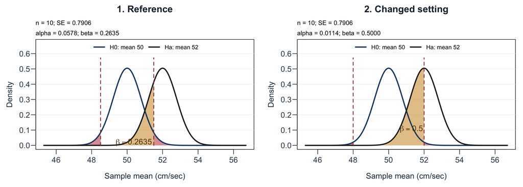

**Fixed $n=10$, $\mu_a=52$.** Widen the nonrejection interval from $[48.5,51.5]$ to $[48,52]$.

The curves keep their shapes. **$\alpha$ decreases:** 0.0578 to 0.0114. **$\beta$ increases:** 0.2635 to 0.5000.

**Prediction:** What happens if we move the boundaries inward?

## Larger sample: Fixed cutoffs, mean 52

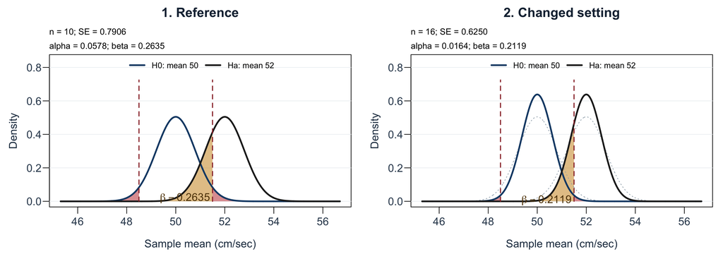

**Fixed $[48.5,51.5]$, $\mu_a=52$.** Increase $n$ from **10 to 16**, so $SE$ changes from **0.7906 to 0.6250**.

Both distributions become narrower and taller. More alternative area lies beyond the upper cutoff.

**$\alpha$ decreases:** 0.0578 to 0.0164. **$\beta$ decreases:** 0.2635 to 0.2119.

## Larger sample: Fixed cutoffs, mean 50.5

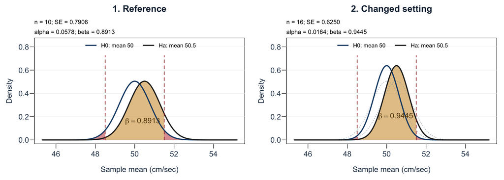

**Fixed $[48.5,51.5]$, $\mu_a=50.5$.** Increase $n$ from **10 to 16**.

**$\alpha$ decreases:** 0.0578 to 0.0164. **$\beta$ increases:** 0.8913 to 0.9445.

The alternative mean lies **inside** the fixed interval. A narrower distribution puts more area inside it.

## Larger sample: Alpha fixed at 0.05

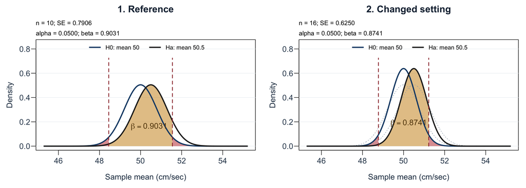

**Fixed $\alpha=0.05$, $\mu_a=50.5$.** Increase $n$ from **10 to 16**.

The critical boundaries $50\pm z_{0.975}(2.5/\sqrt{n})$ move inward. The red area stays **0.05**.

**$\beta$ decreases:** 0.9031 to 0.8741. At fixed $\alpha$, a larger sample improves power for a fixed alternative mean.

## R code patterns

```r
# Two-sided Z-test and confidence interval
SE <- sigma / sqrt(n)
z_obs <- (xbar - mu0) / SE
2 * pnorm(abs(z_obs), lower.tail = FALSE)
xbar + c(-1, 1) * qnorm(0.975) * SE

# Right-tailed t-test and lower confidence bound
SE <- s / sqrt(n)
df <- n - 1
t_obs <- (xbar - mu0) / SE
pt(t_obs, df, lower.tail = FALSE)
xbar - qt(0.95, df) * SE
```

## Source examples

| Lecture | Example | PDF pages |
| --- | --- | --- |
| Class 18 | Light-bulb mean lifetime | 37-47 |
| Class 19 | Battery mean operating life | 16-25 |
| Class 19 | Golf-driver mean COR | 26-33 |
| Class 18, Shiny | Propellant error areas and sample size | 12, 15-17 |

Mean-test outputs and static app comparisons are computed when this file renders. The live Shiny demonstration runs in a separate R session.